# RDA applications in landscape genomics

Thibaut Capblancq & Brenna Forester

Glorious year of 2021

To reproduce the different results and figures of this tutorial you will need to download the following datasets:

- Information on individuals and populations: [Pine_TotemField_AllNaturalIndivResiduals_Jan20th2017.csv](https://datadryad.org/stash/dataset/doi:10.5061/dryad.56j8vq8)
- Genetic matrix for 32,407 SNPs in genic regions: [Pine_AllNatural_GCandTotemIndivs_GWAS_SNPs_June8th2019.txt](https://datadryad.org/stash/dataset/doi:10.5061/dryad.56j8vq8)
- Genetic matrix of 3,934 SNPs in intergenic regions: [Pine_AllNatural_GCandTotemIndivs_ControlSNPs_June8th2019.txt](https://datadryad.org/stash/dataset/doi:10.5061/dryad.56j8vq8)
- Geographic coordinates of sampled source populations: [PlSeedlots.csv](https://datadryad.org/stash/dataset/doi:10.5061/dryad.56j8vq8)
- 27 Climatic rasters from the ClimateNA database (http://climatena.ca), projected in WGS84 coordinate projection (you can reproduce our way to do that using the code in ClimateNA_formatting.R).
- The values of the nine retainded climatic variables (MAR, EMT, MWMT, CMD, Tave_wt, DD_18, MAP, Eref, PAS) in 2012, 2013, 2014 and 2015 at the Vancouver common garden site (latitude = 49.253, longitude = -123.25). You can extract these values using the ClimateNA website (http://www.climatewna.com).

#### Required libraries

```r
library(pegas)
library(ggplot2)
library(raster)
library(rgdal)
library(LEA)
library(rnaturalearth)
library(rnaturalearthdata)
library(RColorBrewer)
library(ggpubr)
library(vegan)
library(qvalue)
library(robust)
library(WMDB)
library(ggVennDiagram)
library(cowplot)
library(corrplot)
library(rgeos)
```

## Loading and formatting data

#### 1.1. Genetic dataset

The genomic data used to search for adaptive loci consisted of 32,407 SNPs genotyped using the AdapTree project lodgepole pine 50K SNP array (Mahony et al. 2020).

**Reminder:** The SNP dataset can be downloaded [here](https://datadryad.org/stash/dataset/doi:10.5061/dryad.56j8vq8).

```r
## Loading genetic dataset
Genotypes <- read.table("./Data/Pine_AllNatural_GCandTotemIndivs_GWAS_SNPs_June8th2019.txt", header = T)
```

```
##     tscaffold5190_95408_105432__8605 scaffold356730_6890_15811__4523
## 1A1                               CT                              AG
## 1A4                               CT                              AG
## 1A6                               CT                              AG
## 1A7                               CC                              AG
## 1A8                               CT                              AG
##     tscaffold5029_74503_82971__2992 scaffold139362_97886_104729__4397
## 1A1                              AA                                TT
## 1A4                              AA                                TT
## 1A6                              AA                                TT
## 1A7                              AA                                00
## 1A8                              AA                                TT
##     tscaffold4182_19129_24843__2762
## 1A1                              GG
## 1A4                              GG
## 1A6                              AG
## 1A7                              AA
## 1A8                              AG
```

We need to convert the genotypes to numeric in order to run RDA. To do so, we will code the count of the minor allele: 0 represents an individual homozygous for the major allele, 1 represents a heterozygote, and 2 is homozygous for the alternative allele.

**Note:** Switching major and minor allele does not affect the RDA-based analyses described below.

```r
## Function to transform the alleles into counts
genotypes2geno <- function(vec) {
  vec <- as.character(vec)
  lev <- levels(as.factor(vec))[-which(levels(as.factor(vec))=="00")]
  vec[vec==lev[1]] <- 0
  vec[vec==lev[2]] <- 1
  vec[vec==lev[3]] <- 2
  vec[vec=="00"] <- NA
  return(as.integer(vec))
}

## Running the function on the lodgepole pine dataset
names_ind <- row.names(Genotypes)
Genotypes <- as.data.frame(apply(Genotypes, 2, genotypes2geno))
row.names(Genotypes) <- names_ind
```

```
##     tscaffold5190_95408_105432__8605 scaffold356730_6890_15811__4523
## 1A1                                1                               1
## 1A4                                1                               1
## 1A6                                1                               1
## 1A7                                0                               1
## 1A8                                1                               1
##     tscaffold5029_74503_82971__2992 scaffold139362_97886_104729__4397
## 1A1                               0                                 2
## 1A4                               0                                 2
## 1A6                               0                                 2
## 1A7                               0                                NA
## 1A8                               0                                 2
##     tscaffold4182_19129_24843__2762
## 1A1                               2
## 1A4                               2
## 1A6                               1
## 1A7                               0
## 1A8                               1
```

The lodgepole pine genetic matrix included individuals that are not part of the common garden experiment. We therefore subset to only those individuals that match the metadata.

**Reminder:** The metadata can be downloaded [here](https://datadryad.org/stash/dataset/doi:10.5061/dryad.56j8vq8)

```r
## Loading samples metadata
InfoInd <- read.table("./Data/Pine_TotemField_AllNaturalIndivResiduals_Jan20th2017.csv", sep = ",", header = T)
Genotypes <- Genotypes[match(InfoInd$Internal_ID, row.names(Genotypes), nomatch = 0),]
```

An RDA model can either be conducted with individual-based genotypes (0, 1, 2 format) or population-based allele frequencies (ranging from 0 to 1). We decided here to work with allele frequencies for the main reason that several individuals were genotyped at each sampling site (i.e., source population) and experienced the exact same climatic conditions. Plus, the sample sizes varied across populations.

```r
## Estimating population allele frequencies
AllFreq <- aggregate(Genotypes, by = list(InfoInd$ProvSeedlotCode), function(x) mean(x, na.rm = T)/2)
row.names(AllFreq) <- as.character(AllFreq$Group.1)
```

RDA does not allow for any missing data in the response or predictor matrices. Here, we start by removing loci with missing data for more than 12/281 populations…

```r
na_pop <- apply(AllFreq[,-1], 2, function(x) sum(is.na(x)))
AllFreq <- AllFreq[,(which(na_pop<12)+1)]
```

…and then imputed the remaining missing data with the median of the locus allele frequencies across all 281 populations. More sophisticated methods exist for imputation, but using the median or the mean (mean not advised for individual-based data) to impute missing genotypes is a common practice when conducting ordination methods.

```r
for (i in 1:ncol(AllFreq))
{
  AllFreq[which(is.na(AllFreq[,i])),i] <- median(AllFreq[-which(is.na(AllFreq[,i])),i], na.rm=TRUE)
}
```

SNPs with a minor allele frequency inferior to 5% were filtered out to avoid giving too much importance to rare alleles when looking for loci associated with environmental variation. Doing so means assuming that local adaptation is driven by consequent changes in adaptive allele frequency along environmental gradients.

```r
## Filtering on MAF
freq_mean <- colMeans(AllFreq)
AllFreq <- AllFreq[,-which(freq_mean>=0.95 | freq_mean<=0.05)]

## Ordering loci based on their scaffold
AllFreq <- AllFreq[,order(colnames(AllFreq))]
```

```
##               C19584417__165 C24254458__306 C27602590_120_505__306
## AB_GSIMS_1956      1.0000000      0.5000000              0.5000000
## AB_GSIMS_2186      0.9583333      0.4444444              0.5416667
## AB_GSIMS_2193      1.0000000      0.3333333              0.5000000
## AB_GSIMS_2206      0.9545455      0.4000000              0.3636364
## AB_GSIMS_2212      0.9666667      0.4642857              0.6250000
##               C27604318_1_471__337 C27741306__179
## AB_GSIMS_1956            1.0000000      0.3750000
## AB_GSIMS_2186            0.9583333      0.4166667
## AB_GSIMS_2193            0.8750000      0.3750000
## AB_GSIMS_2206            0.9583333      0.4000000
## AB_GSIMS_2212            1.0000000      0.3666667
```

The final genetic matrix included allele frequencies for 281 populations (rows) and 29,941 loci (columns).

#### 1.2. Climatic variables

The values of 27 bioclimate variables were extracted for all 281 populations from the [ClimateNA database](http://www.climatena.ca). We had to re-project the rasters into the WGS84 reference coordinate system; see our R code ClimateNA_formating.R if you want/need to do the same.

```r
## Loading the climatic rasters
ras <- stack(list.files("./Data/ClimateNA/", pattern = ".img$", full.names = T))
names(ras) <- unlist(strsplit(unlist(lapply(strsplit(list.files("./Data/ClimateNA/", pattern = ".img$", full.names = T), split = "./Data/ClimateNA//"), function(x) x[2])), split = ".img"))

ras_6190 <- ras[[grep("6190", names(ras))]]
names(ras_6190) <- unlist(strsplit(names(ras_6190), split = "_6190"))
ras_2050 <- ras[[grep("2050_85", names(ras))]]
names(ras_2050) <- unlist(strsplit(names(ras_2050), split = "_2050_85"))
ras_2080 <- ras[[grep("2080_85", names(ras))]]
names(ras_2080) <- unlist(strsplit(names(ras_2080), split = "_2080_85"))
```

A perfect match between non missing pixels in the different climatic rasters is required to facilitate some of the following analyses. To homogenize the different time periods we use the [remove.NAs.stack](https://rdrr.io/github/paleocore-lab/PaleoCore/src/R/remove.NAs.stack.R) function.

```r
remove.NAs.stack<-function(rast.stack){
  nom<-names(rast.stack)
  test1<-calc(rast.stack, fun=sum)
  test1[!is.na(test1)]<-1
  test2<-rast.stack*test1
  test2<-stack(test2)
  names(test2)<-nom
  return(test2)
}
ras_6190 <- remove.NAs.stack(ras_6190)
ras_2050 <- remove.NAs.stack(ras_2050)
ras_2080 <- remove.NAs.stack(ras_2080)
```

The geographic coordinates of each source population are accessible in the PlSeedlots.csv file.

**Reminder:** The PlSeedlots.csv can be downloaded [here](https://datadryad.org/stash/dataset/doi:10.5061/dryad.56j8vq8)

```r
## Source populations coordinates
Coordinates <- read.table("./Data/PlSeedlots.csv", sep = ",", header = T, row.names = 1)
Coordinates <- Coordinates[match(row.names(AllFreq), Coordinates$id2, nomatch = 0),]
colnames(Coordinates) <- c("Population", "Latitude", "Longitude", "Elevation")
```

```
##      Population Latitude Longitude Elevation
## 2 AB_GSIMS_1956   49.667  -110.250      1160
## 3 AB_GSIMS_2186   54.717  -115.417      1160
## 4 AB_GSIMS_2193   53.900  -119.067      1220
## 5 AB_GSIMS_2206   54.650  -118.833      1021
## 6 AB_GSIMS_2212   54.417  -119.000      1189
```

The coordinates were then used to extract climatic data for each pixel/site from the 27 climatic rasters.

```r
## Extracting environmental values for each source population
Env <- data.frame(extract(ras_6190, Coordinates[,3:2]))
```

```
##        AHM     bFFP       CMD     DD_0    DD_18     DD18       DD5     eFFP
## 1 29.78907 151.8185 310.50494 1187.285 5526.946 40.42514 1276.4668 247.0419
## 2 17.44184 145.0000  34.72194 1297.333 5898.447 17.00000 1051.4679 258.0000
## 3 21.29382 159.9837  95.37763 1119.842 5781.278 12.01627  948.0754 251.0000
## 4 20.41969 146.0078  79.24702 1287.774 5718.414 22.96713 1155.0170 255.7625
## 5 17.49811 151.7547  33.98107 1189.037 5794.566 14.24527 1002.6611 257.0000
```

Finally, we standardized the climatic variables to avoid discrepancy in mean and standard deviation among variables (e.g., precipitation in mm and temperature in °C).

**Note:** We have to keep the scaling parameters (i.e., center and scale) to scale present and future climatic data the same way in sections 5 and 6.

```r
## Standardization of the variables
Env <- scale(Env, center=TRUE, scale=TRUE) # center=TRUE, scale=TRUE are the defaults for scale()

## Recovering scaling coefficients
scale_env <- attr(Env, 'scaled:scale')
center_env <- attr(Env, 'scaled:center')

## Climatic table
Env <- as.data.frame(Env)
row.names(Env) <- c(Coordinates$Population)
```

```
##          AHM       bFFP        CMD        DD_0        DD_18        DD18
## 1  1.8870867 -0.4550679  1.3753072 -0.05590561 -0.341482886  0.98088581
## 2 -0.2755355 -0.9800357 -1.3078824  0.18245685  0.161742057 -0.25440734
## 3  0.3991397  0.1735800 -0.7177419 -0.20198508  0.003028699 -0.51721777
## 4  0.2460359 -0.9024430 -0.8746822  0.16175157 -0.082126258  0.06026149
## 5 -0.2656800 -0.4599809 -1.3150906 -0.05211119  0.021027735 -0.39967445
##           DD5       eFFP
## 1  0.92366970 -0.4985623
## 2  0.07742953  0.4654280
## 3 -0.31143860 -0.1503669
## 4  0.46688647  0.2685893
## 5 -0.10613689  0.3774573
```

#### 1.3. Phenotypic traits

The phenotypic data included seedling height and average growth rate measured after three growing seasons (MacLachlan et al. 2017). These data were part of the metadata loaded earlier in this tutorial.

**Note:** Experimental effects were already removed from the phenotypic data using the Best Linear Unbiased Predictions (BLUPs) of a linear mixed model that included block and location within block as random effects (Mahony et al. 2020).

```r
## Estimating mean trait value per population
traits <- aggregate(InfoInd[,19:24], by = list(InfoInd$ProvSeedlotCode), function(x) mean(x, na.rm = T))
traits <- as.data.frame(scale(traits[match(Coordinates$Population, traits$Group.1, nomatch = 0),-1]))
colnames(traits) <- c("Height","GthRate","ShootDryMass","Gth5pct","Gth95pct","ColdInjury")
```

```
##       Height    GthRate ShootDryMass    Gth5pct    Gth95pct ColdInjury
## 1  0.3307265 -0.8217223    1.1893560 -1.7320482  0.14171704        NaN
## 2 -0.5655946 -0.7031858   -0.2140253 -1.1467711 -0.43863258 -1.0772294
## 3 -1.0892930 -1.3039917   -1.2454899  0.2621066 -1.94207413        NaN
## 4  0.5353754  0.7428718    0.8469552 -0.4220947 -0.06169882 -1.1428157
## 5  0.2074397  0.5156596    0.1335810  0.1414286 -0.22332680 -0.5265043
```

#### 1.4. Inferring population structure

To account for population structure in some of the following RDA-based procedures we conducted a principal component analysis (PCA) on the set of 3,934 intergenic SNPs and retained the first three PCs as proxy of population evolutionary history.

**Reminder:** This set of neutral loci can be downloaded [here](https://datadryad.org/stash/dataset/doi:10.5061/dryad.56j8vq8).

```r
## Loading the intergenic SNPs dataset
Neutral <- read.table("./Data/Pine_AllNatural_GCandTotemIndivs_ControlSNPs_June8th2019.txt", header = T)
names_ind_neutral <- row.names(Neutral)

## Formatting genotypes
Neutral <- as.data.frame(apply(Neutral, 2, genotypes2geno))
row.names(Neutral) <- names_ind_neutral

## Sorting genetic data
Neutral <- Neutral[match(InfoInd$Internal_ID, row.names(Neutral), nomatch = 0),]

## Estimating allele frequencies for each source population
AllFreq_neutral <- aggregate(Neutral, by = list(InfoInd$ProvSeedlotCode), function(x) mean(x, na.rm = T)/2)

## Imputation of missing population frequencies by the median across the complete sampling
for (i in 2:ncol(AllFreq_neutral))
{
  AllFreq_neutral[which(is.na(AllFreq_neutral[,i])),i] <- median(AllFreq_neutral[-which(is.na(AllFreq_neutral[,i])),i], na.rm=TRUE)
}
AllFreq_neutral[,-1] <- AllFreq_neutral[,-1][,-which(is.na(colMeans(AllFreq_neutral[,-1])))]
```

**Note:** No filtering on MAF was applied here because small genetic variations are expected to be involved in differentiating neutral genetic groups.

The PCA was then conducted on this neutral genetic matrix.

```r
## Running a PCA on neutral genetic markers
pca <- rda(AllFreq_neutral[,-1], scale=T) # PCA in vegan uses the rda() call without any predictors
```

Screeplot of the PCA eigenvalues:

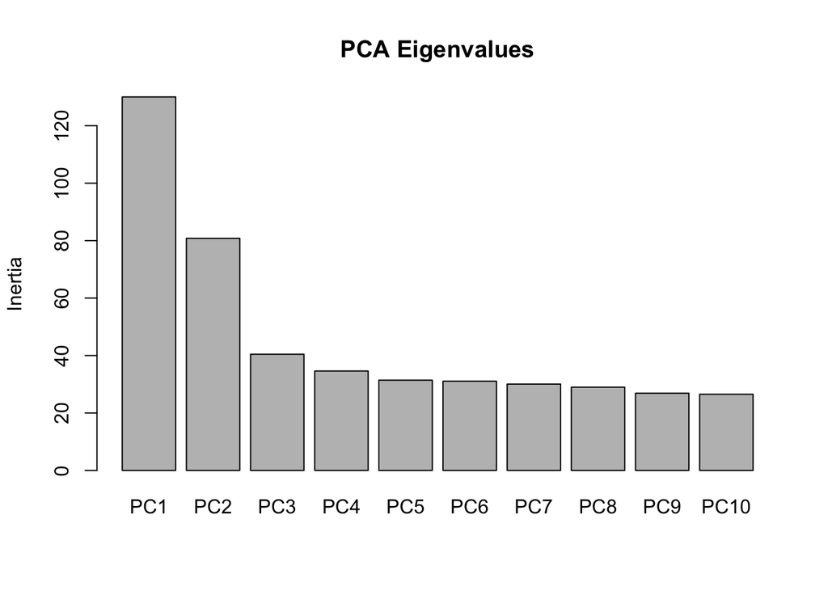

```r
screeplot(pca, type = "barplot", npcs=10, main="PCA Eigenvalues")
```

Based on the screeplot, two or three PCs would be a reasonable set to retain as a proxy for neutral population structure in downstream analyses. In this case, we decided to keep the first three PCs.

```r
## Neutral population structure table
PCs <- scores(pca, choices=c(1:3), display="sites", scaling=0)
PopStruct <- data.frame(Population = AllFreq_neutral[,1], PCs)
colnames(PopStruct) <- c("Population", "PC1", "PC2", "PC3")
```

```
##         Population          PC1           PC2         PC3
## sit1 AB_GSIMS_1956 -0.081181782  0.0323891906 -0.04862294
## sit2 AB_GSIMS_2186 -0.026004421 -0.0009245021  0.03073257
## sit3 AB_GSIMS_2193 -0.038475311  0.0150747541  0.03502343
## sit4 AB_GSIMS_2206  0.001021682  0.0043316411  0.04561589
## sit5 AB_GSIMS_2212 -0.019819786  0.0121817261  0.03271968
```

#### 1.5. Merging all variables into a single table + loading mapping features

```r
## Table gathering all variables
Variables <- data.frame(Coordinates, PopStruct[,-1], Env, traits)
```

```
##      Population Latitude Longitude Elevation          PC1           PC2
## 2 AB_GSIMS_1956   49.667  -110.250      1160 -0.081181782  0.0323891906
## 3 AB_GSIMS_2186   54.717  -115.417      1160 -0.026004421 -0.0009245021
## 4 AB_GSIMS_2193   53.900  -119.067      1220 -0.038475311  0.0150747541
## 5 AB_GSIMS_2206   54.650  -118.833      1021  0.001021682  0.0043316411
## 6 AB_GSIMS_2212   54.417  -119.000      1189 -0.019819786  0.0121817261
##           PC3        AHM       bFFP        CMD        DD_0        DD_18
## 2 -0.04862294  1.8870867 -0.4550679  1.3753072 -0.05590561 -0.341482886
## 3  0.03073257 -0.2755355 -0.9800357 -1.3078824  0.18245685  0.161742057
## 4  0.03502343  0.3991397  0.1735800 -0.7177419 -0.20198508  0.003028699
## 5  0.04561589  0.2460359 -0.9024430 -0.8746822  0.16175157 -0.082126258
## 6  0.03271968 -0.2656800 -0.4599809 -1.3150906 -0.05211119  0.021027735
##          DD18         DD5       eFFP         EMT       Eref        EXT
## 2  0.98088581  0.92366970 -0.4985623 -0.29712475  1.4121550  1.9223158
## 3 -0.25440734  0.07742953  0.4654280 -0.06605395 -0.7103696 -1.2015716
```

[output cut: 27 more lines]

For our analyses we focused on the geographic area occupied by lodgepole pine and used the species range to mask our projections.

```r
## Administrative boundaries
admin <- ne_countries(scale = "medium", returnclass = "sf")

## Species range
range <- readOGR("./Data/pinucon/pinucont.shp")
crs(range) <- '+proj=moll +lon_0=0 +x_0=0 +y_0=0 +ellps=WGS84 +datum=WGS84 +units=m +no_defs'
```

## Variable selection: forward model building procedure

Forward selection starts from a “null” model where the response is explained only by an intercept. Variables are then added to the model one by one to try to reach the amount of variance explained by a “full” model (i.e., model including all the explanatory variables), while limiting the amount of redundancy among included variables.

```r
## Null model
RDA0 <- rda(AllFreq ~ 1,  Variables)

## Full model
RDAfull <- rda(AllFreq ~ AHM + bFFP + CMD + DD_0 + DD_18 + DD18 + DD5 + eFFP + EMT + Eref + EXT + FFP + MAP + MAR + MAT + MCMT + MSP + MWMT + NFFD + PAS + PPT_sm + PPT_wt + RH + SHM + Tave_sm + Tave_wt + TD, Variables)
```

To conduct the selection procedure we used the ordiR2step function of the package vegan and the following stopping criteria: variable significance of p < 0.01 using 1000 permutations, and the adjusted R2 of the global model.

```r
## Stepwise procedure with ordiR2step function
mod <- ordiR2step(RDA0, RDAfull, Pin = 0.01, R2permutations = 1000, R2scope = T)
```

```
##                   R2.adj Df    AIC      F Pr(>F)
## + MAR           0.022036  1 1785.5 7.3092  0.002 **
## + EMT           0.044312  1 1780.0 7.5032  0.002 **
## + MWMT          0.054188  1 1778.1 3.9026  0.002 **
## + CMD           0.062803  1 1776.5 3.5465  0.002 **
## + Tave_wt       0.066927  1 1776.2 2.2199  0.002 **
## + DD_18         0.069881  1 1776.3 1.8732  0.002 **
## + MAP           0.071618  1 1776.8 1.5127  0.002 **
## + Eref          0.073206  1 1777.3 1.4677  0.002 **
## + PAS           0.075014  1 1777.7 1.5317  0.002 **
## <All variables> 0.080705
## ---
## Signif. codes:  0 '***' 0.001 '**' 0.01 '*' 0.05 '.' 0.1 ' ' 1
```

In total, nine of the 27 bioclimate variables were selected: MAR, EMT, MWMT, CMD, Tave_wt, DD_18, MAP, Eref and PAS.

## Variance partitioning: disentangling the drivers of genetic variation

Variance partitioning with partial RDA (pRDA) can identify the contribution of different factors to reducing gene flow and triggering genetic divergence among populations. We apply pRDA-based variance partitioning to the lodgepole pine data to decompose the contribution of climate, neutral population structure, and geography in explaining genetic variation. We used three sets of variables: 1) the nine selected bioclimate variables (‘clim’); 2) three proxies of neutral genetic structure (population scores along the first three axes of a genetic PCA conducted on the 3,934 neutral loci; ‘struct’); and 3) population coordinates (longitude and latitude) to characterize geographic variation (‘geog’).

```r
## Full model
pRDAfull <- rda(AllFreq ~ PC1 + PC2 + PC3 + Longitude + Latitude + MAR + EMT + MWMT + CMD + Tave_wt + DD_18 + MAP + Eref + PAS,  Variables)
RsquareAdj(pRDAfull)
```

```
## $r.squared
## [1] 0.1460961
##
## $adj.r.squared
## [1] 0.1011538
```

```r
anova(pRDAfull)
```

```
## Permutation test for rda under reduced model
## Permutation: free
## Number of permutations: 999
##
## Model: rda(formula = AllFreq ~ PC1 + PC2 + PC3 + Longitude + Latitude + MAR + EMT + MWMT + CMD + Tave_wt + DD_18 + MAP + Eref + PAS, data = Variables)
##           Df Variance      F Pr(>F)
## Model     14    85.27 3.2507  0.001 ***
## Residual 266   498.38
## ---
## Signif. codes:  0 '***' 0.001 '**' 0.01 '*' 0.05 '.' 0.1 ' ' 1
```

```r
## Pure climate model
pRDAclim <- rda(AllFreq ~ MAR + EMT + MWMT + CMD + Tave_wt + DD_18 + MAP + Eref + PAS + Condition(Longitude + Latitude + PC1 + PC2 + PC3),  Variables)
RsquareAdj(pRDAclim)
```

```
## $r.squared
## [1] 0.038964
##
## $adj.r.squared
## [1] 0.01025565
```

```r
anova(pRDAclim)
```

```
## Permutation test for rda under reduced model
## Permutation: free
## Number of permutations: 999
##
## Model: rda(formula = AllFreq ~ MAR + EMT + MWMT + CMD + Tave_wt + DD_18 + MAP + Eref + PAS + Condition(Longitude + Latitude + PC1 + PC2 + PC3), data = Variables)
##           Df Variance      F Pr(>F)
## Model      9    22.74 1.3486  0.001 ***
## Residual 266   498.38
## ---
## Signif. codes:  0 '***' 0.001 '**' 0.01 '*' 0.05 '.' 0.1 ' ' 1
```

```r
## Pure neutral population structure model
pRDAstruct <- rda(AllFreq ~ PC1 + PC2 + PC3 + Condition(Longitude + Latitude + MAR + EMT + MWMT + CMD + Tave_wt + DD_18 + MAP + Eref + PAS),  Variables)
RsquareAdj(pRDAstruct)
```

```
## $r.squared
## [1] 0.03027193
##
## $adj.r.squared
## [1] 0.0214855
```

```r
anova(pRDAstruct)
```

```
## Permutation test for rda under reduced model
## Permutation: free
## Number of permutations: 999
##
## Model: rda(formula = AllFreq ~ PC1 + PC2 + PC3 + Condition(Longitude + Latitude + MAR + EMT + MWMT + CMD + Tave_wt + DD_18 + MAP + Eref + PAS), data = Variables)
##           Df Variance      F Pr(>F)
## Model      3    17.67 3.1433  0.001 ***
## Residual 266   498.38
## ---
## Signif. codes:  0 '***' 0.001 '**' 0.01 '*' 0.05 '.' 0.1 ' ' 1
```

```r
##Pure geography model
pRDAgeog <- rda(AllFreq ~ Longitude + Latitude + Condition(MAR + EMT + MWMT + CMD + Tave_wt + DD_18 + MAP + Eref + PAS + PC1 + PC2 + PC3),  Variables)
RsquareAdj(pRDAgeog)
```

```
## $r.squared
## [1] 0.007262815
##
## $adj.r.squared
## [1] 0.000880208
```

```r
anova(pRDAgeog)
```

```
## Permutation test for rda under reduced model
## Permutation: free
## Number of permutations: 999
##
## Model: rda(formula = AllFreq ~ Longitude + Latitude + Condition(MAR + EMT + MWMT + CMD + Tave_wt + DD_18 + MAP + Eref + PAS + PC1 + PC2 + PC3), data = Variables)
##           Df Variance      F Pr(>F)
## Model      2     4.24 1.1312  0.002 **
## Residual 266   498.38
## ---
## Signif. codes:  0 '***' 0.001 '**' 0.01 '*' 0.05 '.' 0.1 ' ' 1
```

**Note:** It is interesting to look at the degree of correlation among variables using a correlogram

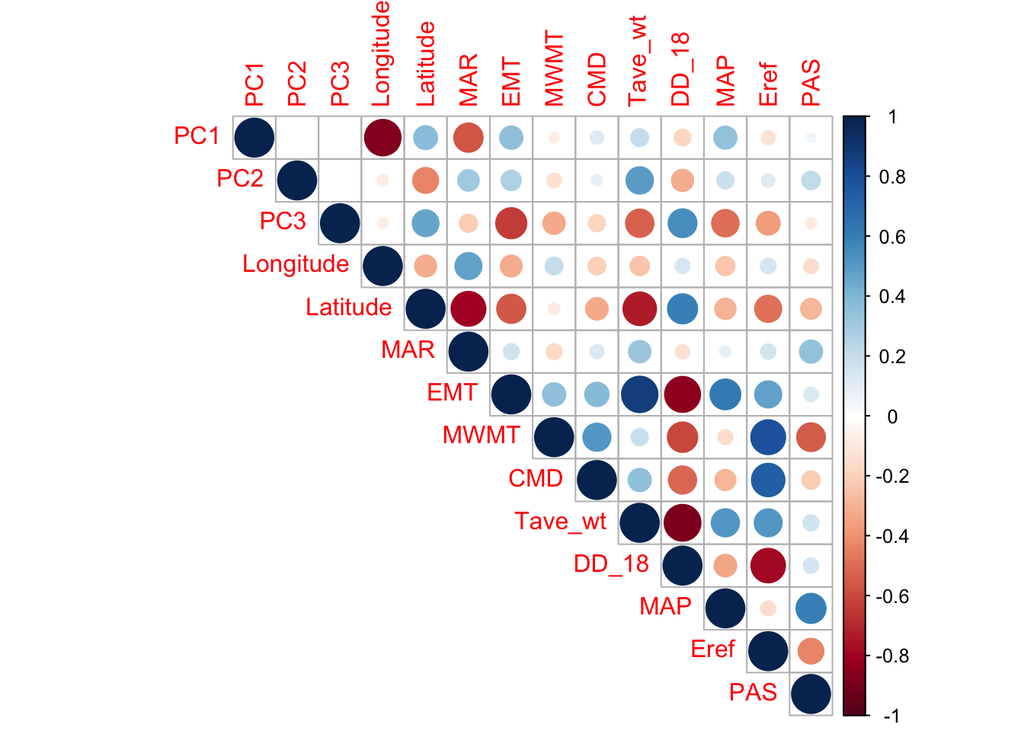

## Genotype-Environment Associations: identifying loci under selection

We used a pRDA to identify candidate adaptive markers in the lodgepole pine data using population allele frequencies for the 29,941 loci as response and the 9 selected bioclimate variables as predictors. We followed the procedure described in Capblancq et al. (2018) where outliers are identified based on their extremeness along a distribution of Mahalanobis distances estimated between each locus and the center of the RDA space using a certain number of axes (K).

Another option for identifying RDA outliers is to search for extreme loadings on each retained axis (e.g., Forester et al., 2018; [vignette and code](https://popgen.nescent.org/2018-03-27_RDA_GEA.html)).

#### 4.1 Conducting the genome scan using pRDA

The first step was to run an RDA model on the allele frequency matrix using the 9 retained climatic factors as explanatory variables and the first three PCs as conditioning variables to account for neutral population structure.

```r
RDA_env <- rda(AllFreq ~ MAR + EMT + MWMT + CMD + Tave_wt + DD_18 + MAP + Eref + PAS + Condition(PC1 + PC2 + PC3),  Variables)
```

We then had to choose a number of RDA axes to include when conducting the genome scan.

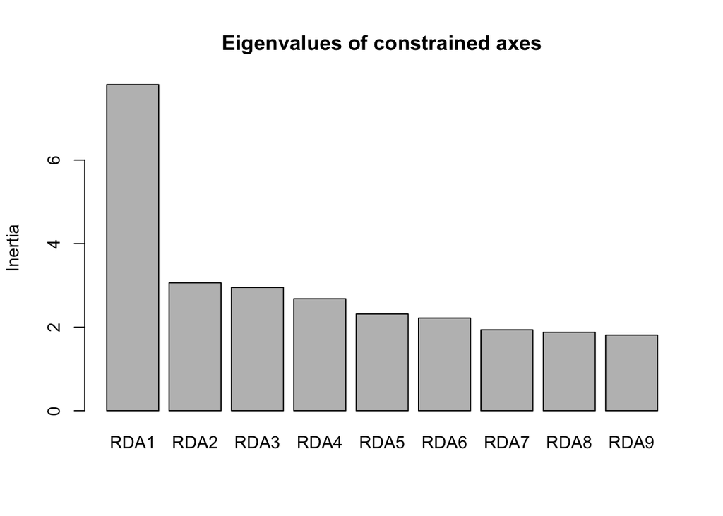

```r
screeplot(RDA_env, main="Eigenvalues of constrained axes")
```

Looking at the proportion of variance explained by each axis, we decided to use the first two axes in this demonstration, though retaining just the first axis, or axes 1-3 would be other reasonable choices. If selecting only one axis, the [axis-based approach](https://popgen.nescent.org/2018-03-27_RDA_GEA.html) mentioned above would be required to identify outliers.

In this case, we can load the rdadapt function, described in Capblancq et al. (2018) and use it to conduct the genome scan.

```r
## Function rdadapt
source("rdadapt.R")

## Running the function with K = 2
rdadapt_env<-rdadapt(RDA_env, 2)
```

One critical step when conducting a genome scan is to set a pertinent p-value threshold to identify the outlier loci. Here, we used a Bonferroni correction to account for multiple testing.

**Note:** the rdadapt function returns both p-values and q-values, which means it is possible to use a FDR (False Discovery Rate) approach instead of a p-value threshold to identify outliers.

```r
## P-values threshold after Bonferroni correction
thres_env <- 0.01/length(rdadapt_env$p.values)

## Identifying the loci that are below the p-value threshold
outliers <- data.frame(Loci = colnames(AllFreq)[which(rdadapt_env$p.values<thres_env)], p.value = rdadapt_env$p.values[which(rdadapt_env$p.values<thres_env)], contig = unlist(lapply(strsplit(colnames(AllFreq)[which(rdadapt_env$p.values<thres_env)], split = "_"), function(x) x[1])))
```

To avoid redundancy among loci that are in strong physical linkage along the genome we only kept the outlier locus with the lowest p-values for each genomic contig.

**Note:** To avoid linkage disequilibrium among loci, it is also possible to prune the dataset before running the genome scan. Here we preferred not to to be able to compare our top hit outliers with previously found adaptive loci that were searched for on a non-pruned dataset.

```r
## Top hit outlier per contig
outliers <- outliers[order(outliers$contig, outliers$p.value),]

## List of outlier names
outliers_rdadapt_env <- as.character(outliers$Loci[!duplicated(outliers$contig)])
```

Once the outliers have been identified, it can be useful to visualize their distribution in comparison with neutral loci using either an RDA biplot or a Manhattan plot.

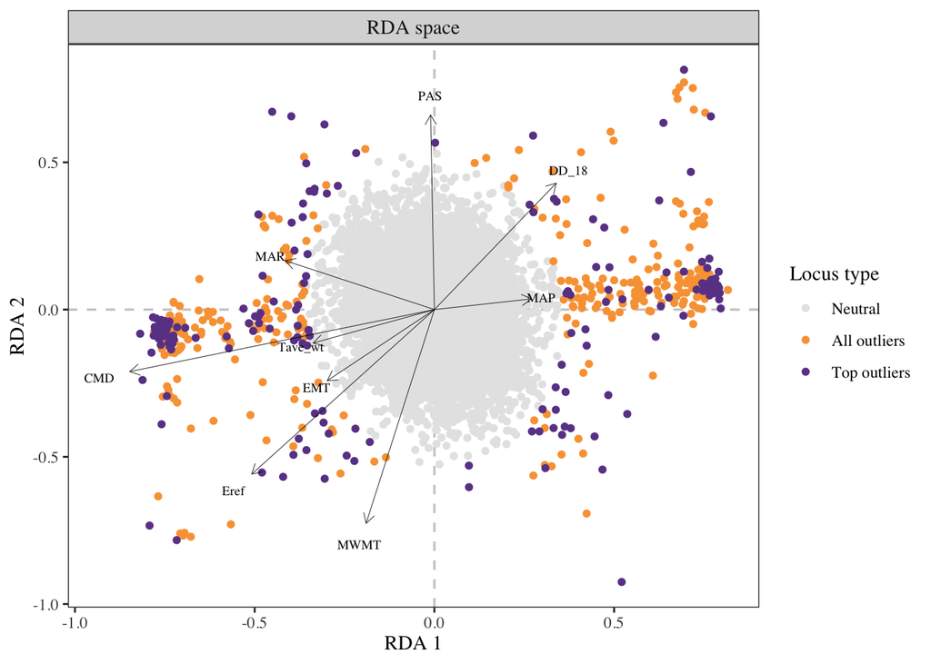

```r
## Formatting table for ggplot
locus_scores <- scores(RDA_env, choices=c(1:2), display="species", scaling="none") # vegan references "species", here these are the loci
TAB_loci <- data.frame(names = row.names(locus_scores), locus_scores)
TAB_loci$type <- "Neutral"
TAB_loci$type[TAB_loci$names%in%outliers$Loci] <- "All outliers"
TAB_loci$type[TAB_loci$names%in%outliers_rdadapt_env] <- "Top outliers"
TAB_loci$type <- factor(TAB_loci$type, levels = c("Neutral", "All outliers", "Top outliers"))
TAB_loci <- TAB_loci[order(TAB_loci$type),]
TAB_var <- as.data.frame(scores(RDA_env, choices=c(1,2), display="bp")) # pull the biplot scores

## Biplot of RDA loci and variables scores
ggplot() +
  geom_hline(yintercept=0, linetype="dashed", color = gray(.80), size=0.6) +
  geom_vline(xintercept=0, linetype="dashed", color = gray(.80), size=0.6) +
  geom_point(data = TAB_loci, aes(x=RDA1*20, y=RDA2*20, colour = type), size = 1.4) +
  scale_color_manual(values = c("gray90", "#F9A242FF", "#6B4596FF")) +
  geom_segment(data = TAB_var, aes(xend=RDA1, yend=RDA2, x=0, y=0), colour="black", size=0.15, linetype=1, arrow=arrow(length = unit(0.02, "npc"))) +
  geom_text(data = TAB_var, aes(x=1.1*RDA1, y=1.1*RDA2, label = row.names(TAB_var)), size = 2.5, family = "Times") +
  xlab("RDA 1") + ylab("RDA 2") +
  facet_wrap(~"RDA space") +
  guides(color=guide_legend(title="Locus type")) +
  theme_bw(base_size = 11, base_family = "Times") +
  theme(panel.background = element_blank(), legend.background = element_blank(), panel.grid = element_blank(), plot.background = element_blank(), legend.text=element_text(size=rel(.8)), strip.text = element_text(size=11))
```

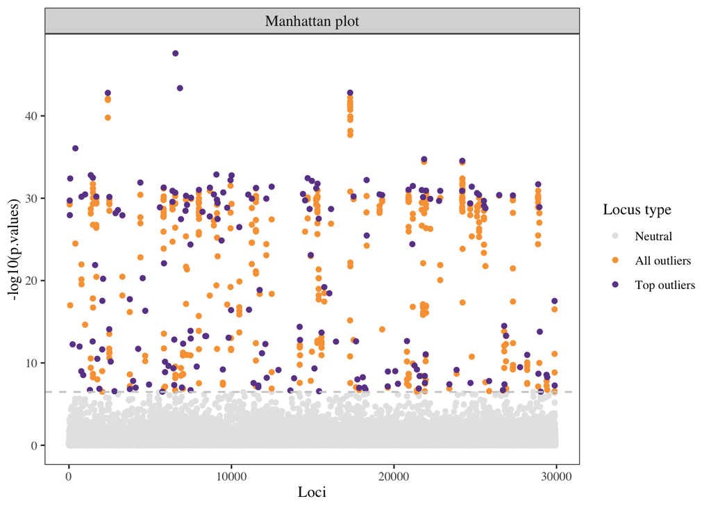

```r
## Manhattan plot
Outliers <- rep("Neutral", length(colnames(AllFreq)))
Outliers[colnames(AllFreq)%in%outliers$Loci] <- "All outliers"
Outliers[colnames(AllFreq)%in%outliers_rdadapt_env] <- "Top outliers"
Outliers <- factor(Outliers, levels = c("Neutral", "All outliers", "Top outliers"))
TAB_manhatan <- data.frame(pos = 1:length(colnames(AllFreq)),
                           pvalues = rdadapt_env$p.values,
                           Outliers = Outliers)
TAB_manhatan <- TAB_manhatan[order(TAB_manhatan$Outliers),]
ggplot(data = TAB_manhatan) +
  geom_point(aes(x=pos, y=-log10(pvalues), col = Outliers), size=1.4) +
  scale_color_manual(values = c("gray90", "#F9A242FF", "#6B4596FF")) +
  xlab("Loci") + ylab("-log10(p.values)") +
  geom_hline(yintercept=-log10(thres_env), linetype="dashed", color = gray(.80), size=0.6) +
  facet_wrap(~"Manhattan plot", nrow = 3) +
  guides(color=guide_legend(title="Locus type")) +
  theme_bw(base_size = 11, base_family = "Times") +
  theme(legend.position="right", legend.background = element_blank(), panel.grid = element_blank(), legend.box.background = element_blank(), plot.background = element_blank(), panel.background = element_blank(), legend.text=element_text(size=rel(.8)), strip.text = element_text(size=11))
```

We identified 583 loci showing extreme association with the environment, reduced to a set of 183 unlinked outliers when retaining only the best hit for each genomic contig.

#### 4.2. Comparing outlier list to Mahony et al. (2020)

```r
## Loading previously identified outliers
outliers_mahony <- read.table("./Data/gea_outliers_by_env_Mahonyetal2020.txt", header = T, row.names = 1)
outliers_mahony_env <- row.names(outliers_mahony)[apply(outliers_mahony[,3:21], 1, function(x) any(as.logical(x)))]
list_outliers <- list(RDA_best = outliers_rdadapt_env, RDA_all = as.character(outliers$Loci), Bayenv2 = outliers_mahony_env)
```

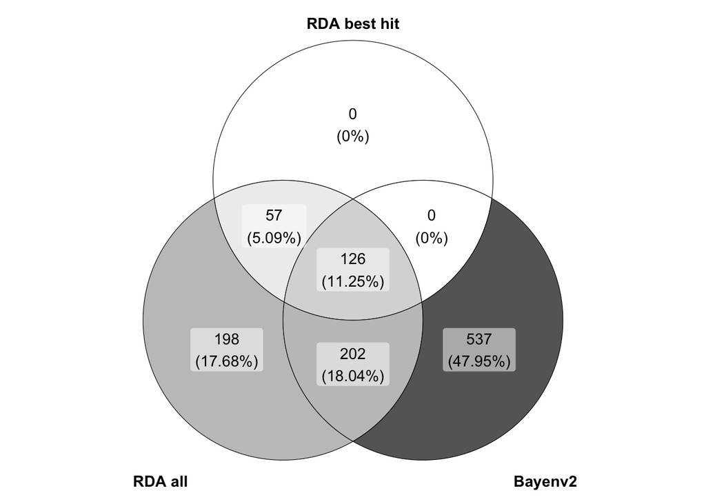

#### 4.3. Not accounting for population structure

In this example, we accounted for population structure, as is commonly recommended when conducting genome scans; however, there are cases where this approach can be overly conservative. To investigate this issue in the lodgepole pine data, we compared the candidates identified with the partial RDA to those identified using a simple RDA.

```r
## Running a simple RDA model
RDA_env_unconstrained <- rda(AllFreq ~ MAR + EMT + MWMT + CMD + Tave_wt + DD_18 + MAP + Eref + PAS,  Variables)

## Running the rdadapt function
rdadapt_env_unconstrained <- rdadapt(RDA_env_unconstrained, 2)

## Setting the p-value threshold
thres_env <- 0.01/length(rdadapt_env_unconstrained$p.values)

## Identifying the outliers for the simple RDA
outliers_unconstrained <- data.frame(Loci = colnames(AllFreq)[which(rdadapt_env_unconstrained$p.values<thres_env)], p.value = rdadapt_env_unconstrained$p.values[which(rdadapt_env_unconstrained$p.values<thres_env)], contig = unlist(lapply(strsplit(colnames(AllFreq)[which(rdadapt_env_unconstrained$p.values<thres_env)], split = "_"), function(x) x[1])))
outliers_unconstrained <- outliers_unconstrained[order(outliers_unconstrained$contig, outliers_unconstrained$p.value),]
outliers_rdadapt_env_unconstrained <- as.character(outliers_unconstrained$Loci[!duplicated(outliers_unconstrained$contig)])
```

We then compared the outliers identified when accounting or not for population structure.

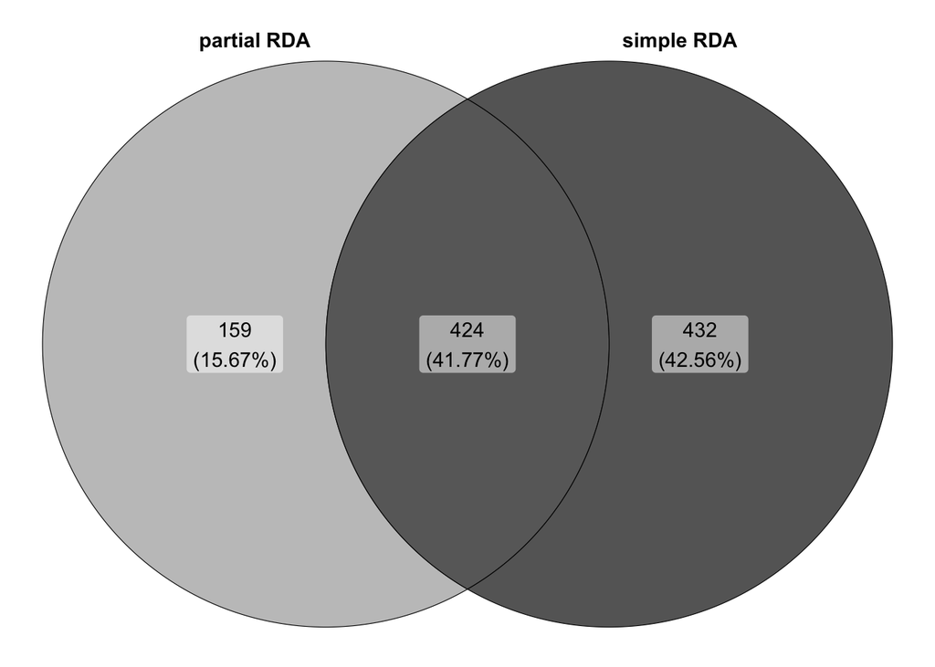

```r
## For all the outliers
list_outliers_RDA_all <- list(RDA_constrained = as.character(outliers$Loci), RDA_unconstrained = as.character(outliers_unconstrained$Loci))
ggVennDiagram(list_outliers_RDA_all, category.names = c("partial RDA", "simple RDA"), lty="solid", color="black", size=0.2) +
  scale_fill_gradient2(low = "white", high = 'gray40') + guides(fill = FALSE) + theme(text = element_text(size=16, family = "Times"))
```

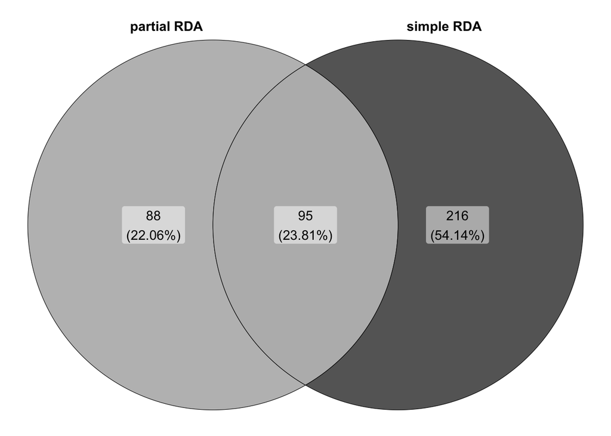

```r
## Only for the top hit locus per contig
list_outliers_RDA_top <- list(RDA_constrained = outliers_rdadapt_env, RDA_unconstrained = outliers_rdadapt_env_unconstrained)
ggVennDiagram(list_outliers_RDA_top, category.names = c("partial RDA", "simple RDA"), lty="solid", color="black", size=0.2) +
  scale_fill_gradient2(low = "white", high = 'gray40') + guides(fill = FALSE) + theme(text = element_text(size=16, family = "Times"))
```

For all of the following RDA-based analyses we decided to retain only the 95 loci that were detected by both the partial RDA that accounted for population structure and by the simple RDA that did not account for population structure.

**Note:** Decisions about if and how to correct for population structure, how to set outlier thresholds, and how to finalize a set of candidate adaptive markers will depend upon the objectives of the study and the data available (if any) for validation. The approach presented here is not meant to be applied without modification; modeling parameters and other decisions should be determined based on the characteristics of the data and the goals of the study.

```r
common_outliers_RDA_top <- Reduce(intersect, list_outliers_RDA_top)
```

```
##  [1] "C31411078_145_3259__543"
##  [2] "C31599546_4573_7685__2723"
##  [3] "C32149882_2801_5098__1880"
##  [4] "C32362222_9849_24074__6724"
##  [5] "C32433704_2294_9337__4068"
##  [6] "C32512542_63900_64598__265"
##  [7] "C32528064_18901_23330__2851"
##  [8] "C32530314_45451_50445__1499"
##  [9] "C32543176_18338_19805__239"
## [10] "C32571330_91426_100731__3710"
## [11] "C32572246_186975_193712__1959"
## [12] "scaffold111047_18861_22501__2722"
## [13] "scaffold11915_58120_61584__1407"
## [14] "scaffold133090_50563_54310__504"
## [15] "scaffold138496_18058_21605__888"
```

[output cut: 80 more lines]

## Adaptive landscape: projecting adaptive gradient(s) across space

#### 5.1. Adaptively enriched genetic space

The 95 putative adaptive loci were used as multivariate response in a new “adaptively enriched” RDA, using the 9 selected bioclimate variables as explanatory variables.

```r
## Adaptively enriched RDA
RDA_outliers <- rda(AllFreq[,common_outliers_RDA_top] ~ MAR + EMT + MWMT + CMD + Tave_wt + DD_18 + MAP + Eref + PAS,  Variables)
```

An RDA biplot allows us to visualize the relationship between the 95 putative adaptive loci and the underlying climatic variables.

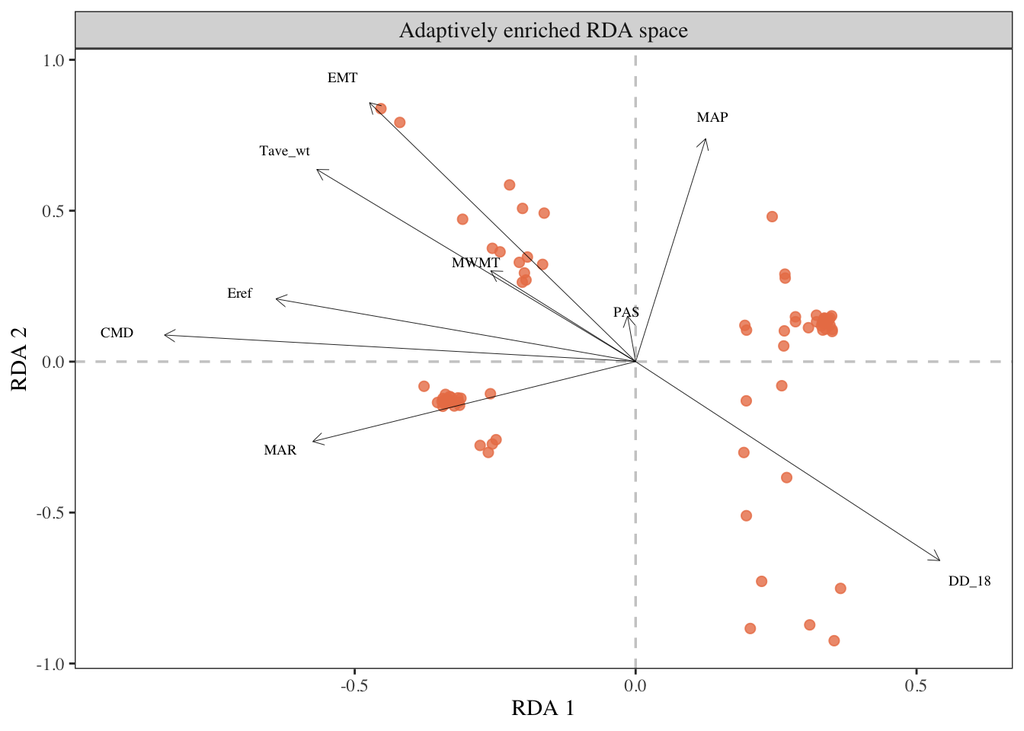

```r
## RDA biplot
TAB_loci <- as.data.frame(scores(RDA_outliers, choices=c(1:2), display="species", scaling="none"))
TAB_var <- as.data.frame(scores(RDA_outliers, choices=c(1:2), display="bp"))
ggplot() +
  geom_hline(yintercept=0, linetype="dashed", color = gray(.80), size=0.6) +
  geom_vline(xintercept=0, linetype="dashed", color = gray(.80), size=0.6) +
  geom_point(data = TAB_loci, aes(x=RDA1*3, y=RDA2*3), colour = "#EB8055FF", size = 2, alpha = 0.8) + #"#F9A242FF"
  geom_segment(data = TAB_var, aes(xend=RDA1, yend=RDA2, x=0, y=0), colour="black", size=0.15, linetype=1, arrow=arrow(length = unit(0.02, "npc"))) +
  geom_text(data = TAB_var, aes(x=1.1*RDA1, y=1.1*RDA2, label = row.names(TAB_var)), size = 2.5, family = "Times") +
  xlab("RDA 1") + ylab("RDA 2") +
  facet_wrap(~"Adaptively enriched RDA space") +
  guides(color=guide_legend(title="Locus type")) +
  theme_bw(base_size = 11, base_family = "Times") +
  theme(panel.grid = element_blank(), plot.background = element_blank(), panel.background = element_blank(), strip.text = element_text(size=11))
```

#### 5.2. Adaptive index across the landscape

The scores of the environmental variables along the RDA axes can be used to calculate a genetic-based index of adaptation for each environmental pixel of the landscape. This index is estimated independently for each RDA axis of interest using the formula:
$$\sum_{i = 1}^{n}{a_ib_i}$$
Where *a* is the climatic variable score (loading) along the RDA axis, *b* is the standardized value for this particular variable at the focal pixel, and *i* refers to one of the *n* different variables used in the RDA model.

```r
## Function to predict the adaptive index across the landscape
source("adaptive_index.R")

## Running the function for all the climatic pixels of lodgepole pine distribution range
res_RDA_proj_current <- adaptive_index(RDA = RDA_outliers, K = 2, env_pres = ras_6190, range = range, method = "loadings", scale_env = scale_env, center_env = center_env)
```

The adaptive index thus provides an estimate of adaptive genetic similarity or difference of all pixels on the landscape as a function of the values of the environmental predictors at that location. When projected on a map it allows visualizing the different adaptive gradients across a species range.

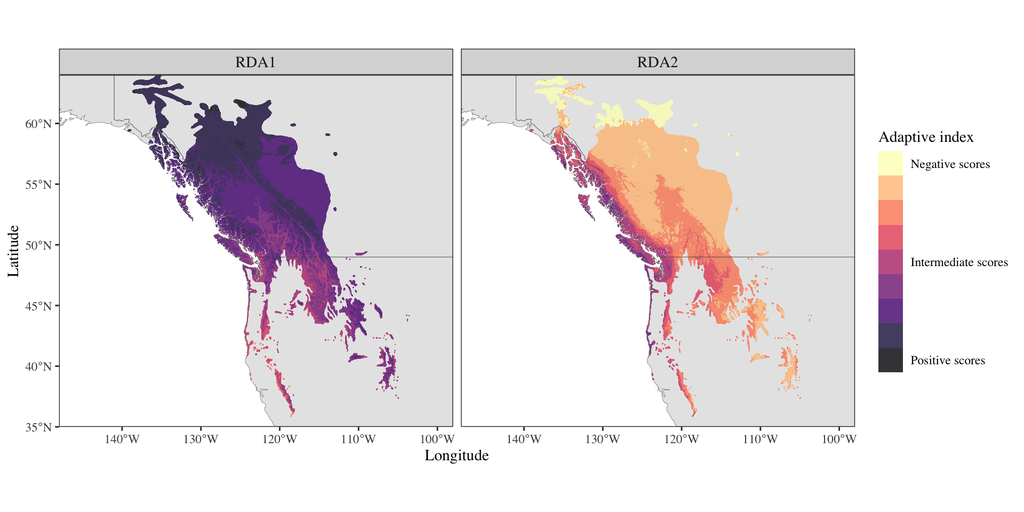

```r
## Vectorization of the climatic rasters for ggplot
RDA_proj <- list(res_RDA_proj_current$RDA1, res_RDA_proj_current$RDA2)
RDA_proj <- lapply(RDA_proj, function(x) rasterToPoints(x))
for(i in 1:length(RDA_proj)){
  RDA_proj[[i]][,3] <- (RDA_proj[[i]][,3]-min(RDA_proj[[i]][,3]))/(max(RDA_proj[[i]][,3])-min(RDA_proj[[i]][,3]))
}

## Adaptive genetic turnover projected across lodgepole pine range for RDA1 and RDA2 indexes
TAB_RDA <- as.data.frame(do.call(rbind, RDA_proj[1:2]))
colnames(TAB_RDA)[3] <- "value"
TAB_RDA$variable <- factor(c(rep("RDA1", nrow(RDA_proj[[1]])), rep("RDA2", nrow(RDA_proj[[2]]))), levels = c("RDA1","RDA2"))
ggplot(data = TAB_RDA) +
  geom_sf(data = admin, fill=gray(.9), size=0) +
  geom_raster(aes(x = x, y = y, fill = cut(value, breaks=seq(0, 1, length.out=10), include.lowest = T))) +
  scale_fill_viridis_d(alpha = 0.8, direction = -1, option = "A", labels = c("Negative scores","","","","Intermediate scores","","","","Positive scores")) +
  geom_sf(data = admin, fill=NA, size=0.1) +
  coord_sf(xlim = c(-148, -98), ylim = c(35, 64), expand = FALSE) +
  xlab("Longitude") + ylab("Latitude") +
  guides(fill=guide_legend(title="Adaptive index")) +
  facet_grid(~ variable) +
  theme_bw(base_size = 11, base_family = "Times") +
  theme(panel.grid = element_blank(), plot.background = element_blank(), panel.background = element_blank(), strip.text = element_text(size=11))
```

## Predicting local maladaptation: genomic offset

#### 6.1. Predicting future genomic offset

Once the genetic ~ environment relationship is characterized, it can be extrapolated to future environments to predict a potential shift in adaptive optimum induced by climate change.The RDA-based method to predict this future maladaptation is relatively simple. As done above, RDA can be used to predict the optimal adaptive genetic composition for each environmental pixel under consideration (Adaptive Index in Section 5), using both current and future environmental conditions. The difference between the two predictions provides an estimate of the change in genetic composition that would be required to track climate change.

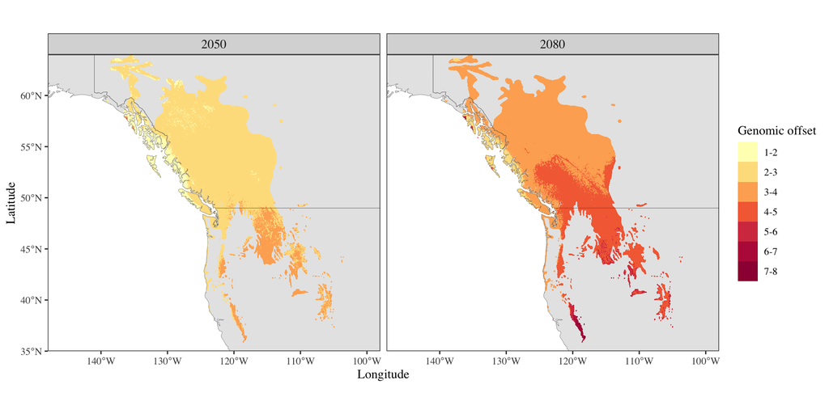

```r
## Function to predict genomic offset from a RDA model
source("genomic_offset.R")

## Running the function for 2020 and 2080
res_RDA_proj2080 <- genomic_offset(RDA_outliers, K = 2, env_pres = ras_6190, env_fut = ras_2080, range = range, method = "loadings", scale_env = scale_env, center_env = center_env)
res_RDA_proj2050 <- genomic_offset(RDA_outliers, K = 2, env_pres = ras_6190, env_fut = ras_2050, range = range, method = "loadings", scale_env = scale_env, center_env = center_env)

## Table global genetic offset predicted for 2050 and 2080
RDA_proj_offset <- data.frame(rbind(rasterToPoints(res_RDA_proj2050$Proj_offset_global), rasterToPoints(res_RDA_proj2080$Proj_offset_global)), Date = c(rep("2050", nrow(rasterToPoints(res_RDA_proj2050$Proj_offset_global))), rep("2080", nrow(rasterToPoints(res_RDA_proj2080$Proj_offset_global)))))

## Projecting genomic offset on a map
colors <- c(colorRampPalette(brewer.pal(11, "Spectral")[6:5])(2), colorRampPalette(brewer.pal(11, "Spectral")[4:3])(2), colorRampPalette(brewer.pal(11, "Spectral")[2:1])(3))
ggplot(data = RDA_proj_offset) +
  geom_sf(data = admin, fill=gray(.9), size=0) +
  geom_raster(aes(x = x, y = y, fill = cut(Global_offset, breaks=seq(1, 8, by = 1), include.lowest = T)), alpha = 1) +
  scale_fill_manual(values = colors, labels = c("1-2","2-3","3-4","4-5","5-6","6-7","7-8"), guide = guide_legend(title="Genomic offset", title.position = "top", title.hjust = 0.5, ncol = 1, label.position="right"), na.translate = F) +
  geom_sf(data = admin, fill=NA, size=0.1) +
  coord_sf(xlim = c(-148, -98), ylim = c(35, 64), expand = FALSE) +
  xlab("Longitude") + ylab("Latitude") +
  facet_grid(~ Date) +
  theme_bw(base_size = 11, base_family = "Times") +
  theme(panel.grid = element_blank(), plot.background = element_blank(), panel.background = element_blank(), strip.text = element_text(size=11))
```

#### 6.2. Predicting geographic genomic offset

A challenge associated with any predictive method is to find ways to validate the predictions. Here, we took advantage of the common garden experiment conducted in lodgepole pine to test our genomic offset predictions. We estimated a geographic genomic offset between the climate of each source population (based on the average between 1960 and 1990) and the climate of the garden where the seedlings were grown (in Vancouver, BC, Canada, averaging the years 2012 to 2015) and were then able to test the influence of the predicted genomic offset on the seedling fitness traits.

```r
env <- row.names(scores(RDA_outliers, choices=c(1:2), display="bp"))

## Environmental variables for the period the seedlings were growing in the common garden (2012-2015)
env_garden <- read.table("./Data/ClimateData_VancouverGarden.csv", sep = ",", header = T)
env_garden <- env_garden[, env]
env_garden$MAR <- extract(ras_6190[[env]]$MAR, c(-123.250, 49.256))[2]
env_garden <- as.data.frame(scale(env_garden, center = center_env[env], scale = scale_env[env]))
env_garden <- colMeans(env_garden)

## Environmental variables for the source populations between 61 and 90
env_provenance <- data.frame(extract(ras_6190[[env]], Variables[,c("Longitude", "Latitude")]))
env_provenance <- as.data.frame(scale(env_provenance, center_env[env], scale_env[env]))
row.names(env_provenance) <- Variables[,"Population"]
```

Based on the adaptively enriched RDA space, we estimated a distance between each source population and the common garden climatic conditions.

```r
## Function to estimate genetic offset between provenance and garden
source("provgar_offset.R")

## Running the provenance to garden genetic offset function
provgar_offset <- provgar_offset(RDA = RDA_outliers, K = 2, env_garden = env_garden, env_provenance = env_provenance, weights = TRUE)
```

This geographic genomic offset can then be compared to different fitness traits in the garden to estimate the impact of this predicted maladaptation on seedling fitness. We can also compare the influence of genomic offset on fitness with the impact of a basic climate transfer distance estimated between each source population and the garden from the climatic variables only (using Mahalanobis distance).

```r
## Climate distance between provenances and garden
tabmaha <- as.data.frame(rbind(env_garden, env_provenance))
mahaclim <- mahalanobis(as.matrix(tabmaha), center = as.numeric(tabmaha[1,]), cov = cov(as.matrix(tabmaha)))

## Comparison climate transfer vs. genomic offset impact on fitness
TAB_comp <- data.frame(x = rep(c(mahaclim[-1], provgar_offset[-1]), 2), y = c(rep(traits$Height, 2), rep(traits$GthRate, 2)), method = rep(rep(c("Climate", "Genetics"), each = nrow(traits)), 2), variable = rep(c("Final height", "Growth rate"), each = 2*nrow(traits)))
p_garden <- ggplot(TAB_comp, aes(x=x, y=y)) +
  geom_point(shape=19, size = 2, alpha = .7) +
  geom_smooth(method = "lm", formula = y ~ x + I(x^2), size = 1) +
  facet_grid(variable ~ method, scales = "free") +
  ylab("Scaled fitness trait value") +
  xlab("Climate transfer distance                              Genomic offset") +
  theme_bw(base_size = 12, base_family = "Times") +
  theme(panel.grid = element_blank(), panel.background = element_blank())
```

```r
## Quadratic regression statistical testing
summary(lm(traits$Height ~ poly(mahaclim[-1])))
```

```
##
## Call:
## lm(formula = traits$Height ~ poly(mahaclim[-1]))
##
## Residuals:
##     Min      1Q  Median      3Q     Max
## -2.2795 -0.7389 -0.1197  0.5975  3.3945
##
## Coefficients:
##                      Estimate Std. Error t value Pr(>|t|)
## (Intercept)        -2.846e-17  5.955e-02    0.00     1.00
## poly(mahaclim[-1]) -1.407e+00  9.982e-01   -1.41     0.16
##
## Residual standard error: 0.9982 on 279 degrees of freedom
## Multiple R-squared:  0.007072,   Adjusted R-squared:  0.003513
## F-statistic: 1.987 on 1 and 279 DF,  p-value: 0.1598
```

```r
summary(lm(traits$Height ~ poly(provgar_offset[-1])))
```

```
##
## Call:
## lm(formula = traits$Height ~ poly(provgar_offset[-1]))
##
## Residuals:
##     Min      1Q  Median      3Q     Max
## -2.7167 -0.6189 -0.0824  0.5463  3.2159
##
## Coefficients:
##                            Estimate Std. Error t value Pr(>|t|)
## (Intercept)              -1.602e-16  5.592e-02   0.000        1
## poly(provgar_offset[-1]) -5.903e+00  9.374e-01  -6.297 1.18e-09 ***
## ---
## Signif. codes:  0 '***' 0.001 '**' 0.01 '*' 0.05 '.' 0.1 ' ' 1
##
## Residual standard error: 0.9374 on 279 degrees of freedom
## Multiple R-squared:  0.1244, Adjusted R-squared:  0.1213
## F-statistic: 39.65 on 1 and 279 DF,  p-value: 1.177e-09
```

```r
summary(lm(traits$GthRate ~ poly(mahaclim[-1])))
```

```
##
## Call:
## lm(formula = traits$GthRate ~ poly(mahaclim[-1]))
##
## Residuals:
##     Min      1Q  Median      3Q     Max
## -2.8871 -0.6664 -0.0001  0.5502  4.0467
##
## Coefficients:
##                      Estimate Std. Error t value Pr(>|t|)
## (Intercept)         1.882e-17  5.946e-02    0.00   1.0000
## poly(mahaclim[-1]) -1.684e+00  9.967e-01   -1.69   0.0922 .
## ---
## Signif. codes:  0 '***' 0.001 '**' 0.01 '*' 0.05 '.' 0.1 ' ' 1
##
## Residual standard error: 0.9967 on 279 degrees of freedom
## Multiple R-squared:  0.01013,    Adjusted R-squared:  0.006583
## F-statistic: 2.855 on 1 and 279 DF,  p-value: 0.09219
```

```r
summary(lm(traits$GthRate ~ poly(provgar_offset[-1])))
```

```
##
## Call:
## lm(formula = traits$GthRate ~ poly(provgar_offset[-1]))
##
## Residuals:
##     Min      1Q  Median      3Q     Max
## -3.4259 -0.5833  0.0080  0.5347  3.0109
##
## Coefficients:
##                            Estimate Std. Error t value Pr(>|t|)
## (Intercept)              -1.457e-16  5.362e-02   0.000        1
## poly(provgar_offset[-1]) -7.386e+00  8.989e-01  -8.217 7.92e-15 ***
## ---
## Signif. codes:  0 '***' 0.001 '**' 0.01 '*' 0.05 '.' 0.1 ' ' 1
##
## Residual standard error: 0.8989 on 279 degrees of freedom
## Multiple R-squared:  0.1948, Adjusted R-squared:  0.192
## F-statistic: 67.51 on 1 and 279 DF,  p-value: 7.916e-15
```

We found that genomic offset better explained the decrease in height and growth rate than the basic climate transfer distance, which confirms the great potential of genomic offset for selecting source population for management or conservation plans.